# Gransker trege responstider, ytelsestester for OGC

Her konsentrerer vi oss om å finne hva som særpreger de trege målingene - dem som IKKE tilfredsstiller kravet vårt om maks to sekunders responstid for OGC karttjenester.

Jeg har sett på loggene i mappen

`O:\IT\Prod og tj\EEA60 IT Veg og transport\80 Produkt og tjenesteportefølje\OGC Karttjenester\00 - Dokumentasjon\Ytelsestester\Akseptansetest\Endelige tester`

```python
import pandas as pd
from io import StringIO
import matplotlib.pyplot as plt
```

Vi har tre mapper med fil `simulation.log`, la oss kalle dem Mappe 1, Mappe2 og Mappe 3.

```python
mappenavn = ['Endelige tester/Test oppjustert 4 noder 4GB minne og 400millicores - 200rps (60 min)/',
             'Endelige tester/Test oppjustert 4 noder 4GB minne og 400millicores - 200rps (60 min) (2)/',
             'Endelige tester/Test oppjustert 4 noder 4GB minne og 400millicores - 200rps (60 min) (3)/' ]

logfilnavn = 'simulation.log'
```

```python
mydfs = []
for (ix, mappe) in enumerate(mappenavn):
    with open(mappe+logfilnavn) as f:
        text = "\n".join([line for line in f if 'REQUEST' in line])
    mydf = pd.read_csv(StringIO(text), header=0, names=['type', 'verb', 'kartlag', 'start', 'slutt', 'status'],  delim_whitespace=True)
    mydf['mappe'] = 'Mappe' + str( ix+1)
    mydfs.append( mydf )
mydf = pd.concat( mydfs )
mydf['Responstid'] = (mydf['slutt'] - mydf['start'])/1000
```

### Fordeling mellom de ulike kartlagene

```python
mydf.groupby( ['mappe', 'kartlag'] ).agg( { 'status' : 'count'} )
```

| mappe | kartlag | status |
| --- | --- | --- |
| Mappe1 | Reisetid | 501996 |
|  | Trafikkmeldinger | 213042 |
| Mappe2 | Reisetid | 498448 |
|  | Trafikkmeldinger | 212778 |
| Mappe3 | Reisetid | 502119 |
|  | Trafikkmeldinger | 213073 |

Hver loggfil inneholder om lag en halv million spørringer mot kartlag reisetid og 200.000 spørringer mot kartlag Trafikkmeldinger

```python
mydf['Responstid'].describe()
```

```
count    2.141456e+06
mean     1.403918e-01
std      6.286781e-01
min      1.400000e-02
25%      6.700000e-02
50%      9.000000e-02
75%      1.250000e-01
max      3.513200e+01
Name: Responstid, dtype: float64
```

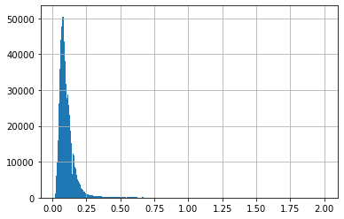

```python
ax1 = mydf[ mydf['Responstid'] < 2 ]['Responstid'].hist( bins=1000)
```

Ser helt greit ut, hovedtyngde av målinger ligger mellom 50 og 250 millisekund (25- og 75 percentil på 67 og 125 ms).

### 2.1 millioner målinger, hvor mange av dem feila?

```python
mydf['status'].value_counts()
```

```
OK    2141456
Name: status, dtype: int64
```

### Ser nærmere på de trege målingene, > 2s

```python
mydf[ mydf['Responstid'] > 2]['Responstid'].describe()
```

```
count    10213.000000
mean         5.756202
std          6.934566
min          2.001000
25%          2.470000
50%          3.222000
75%          4.790000
max         35.132000
Name: Responstid, dtype: float64
```

```python
print( round( 100*len( mydf[ mydf['Responstid'] > 2])/len(mydf), 2),
      '% av målingene er tregere enn kravet på 2 sekund'  )
print( '\nPercentiler:')
print( '95% er bedre enn',   round( mydf['Responstid'].quantile(0.95), 1), 's' )
print( '99% er bedre enn',   round( mydf['Responstid'].quantile(0.99), 1), 's' )
print( '99.5% er bedre enn', round( mydf['Responstid'].quantile(0.995), 1), 's' )
print( '99.9% er bedre enn', round( mydf['Responstid'].quantile(0.999), 1), 's' )
```

```
0.48 % av målingene er tregere enn kravet på 2 sekund

Percentiler:
95% er bedre enn 0.2 s
99% er bedre enn 1.0 s
99.5% er bedre enn 1.9 s
99.9% er bedre enn 5.3 s
```

## 10000 av 2.1 million - 0.5% - er tregere enn kravet på 2 sekunder. Dvs 99.5% av målingene tilfredsstiller kravet.

Vi zoomer inn på de målingene som IKKE tilfredsstiller kravet, dvs tregere enn 2 sekund

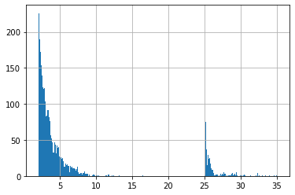

```python
junk = mydf[ mydf['Responstid'] > 2]['Responstid'].hist( bins=1000)
```

#### Hm, her var det noen VELDIG pussige målinger fra 25 sekund og utover.

Vi har den forventede asymptotiske halen, og har færre enn 50 målinger i området 10 - 25 sekund. Men så har vi plutselig 1000 målinger over 25 sekund?

```python
print( len( mydf[ (mydf['Responstid'] > 10) & (mydf['Responstid'] < 25 )] ), '\tmålinger i området 10-25 sekund',)
print( len( mydf[ (mydf['Responstid'] > 25)] ),  '\tmålinger > 25 sekund' )
```

```
45 	målinger i området 10-25 sekund
1000 	målinger > 25 sekund
```

#### La oss se hvordan målingene fordeler seg på kartlag og de tre ulike måleseriene (mappe 1, 2 og 3)

```python
mydf[ mydf['Responstid'] > 2].groupby( 'kartlag').agg( {'status' : 'count'})
```

| kartlag | status |
| --- | --- |
| Reisetid | 3193 |
| Trafikkmeldinger | 7020 |

Det er over dobbelt så mange trege målinger av trafikkmelding-spørringer enn reisetid, noe pussig når de utgjør totalt 30% av spørringene

```python
mydf[ mydf['Responstid'] > 2 ].groupby( ['mappe', 'kartlag'] ).agg( { 'status' : 'count'} )
```

| mappe | kartlag | status |
| --- | --- | --- |
| Mappe1 | Reisetid | 1769 |
|  | Trafikkmeldinger | 2283 |
| Mappe2 | Reisetid | 994 |
|  | Trafikkmeldinger | 2844 |
| Mappe3 | Reisetid | 430 |
|  | Trafikkmeldinger | 1893 |

```python
mydf[ mydf['Responstid'] > 25 ].groupby( ['mappe', 'kartlag'] ).agg( { 'status' : 'count'} )
```

| mappe | kartlag | status |
| --- | --- | --- |
| Mappe2 | Reisetid | 477 |
|  | Trafikkmeldinger | 523 |

De **virkelig** trege spørringene finnes kun i mappe 2, men her er det om lag halvt om halvt med reisetid og trafikkmeldinger.

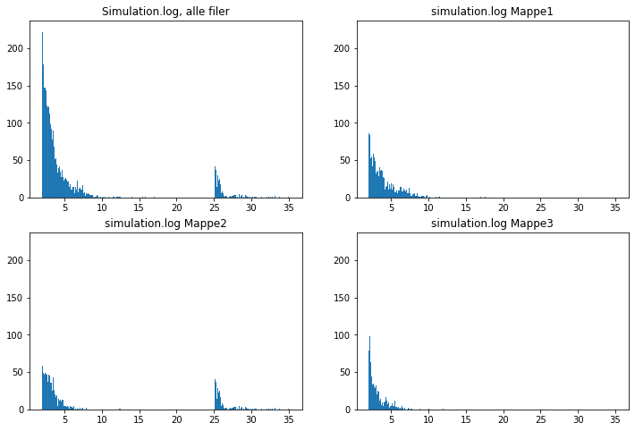

```python
fig, axs = plt.subplots(nrows=2, ncols=2, figsize=(12, 8))

(hist_n, hist_bins, hist_range) = axs[0][0].hist( mydf[ mydf['Responstid'] > 2]['Responstid'], bins=1000 )
axs[0][0].set_title( 'Simulation.log, alle filer')

(junk, junk, junk) = axs[0][1].hist( mydf[ (mydf['Responstid'] > 2) & (mydf['mappe'] == 'Mappe1')]['Responstid'], bins=hist_bins, range=hist_range )
axs[0][1].set_title( 'simulation.log Mappe1')
junk = axs[0][1].set_ylim( axs[0][0].get_ylim())

(junk, junk, junk) = axs[1][0].hist( mydf[ (mydf['Responstid'] > 2) & (mydf['mappe'] == 'Mappe2')]['Responstid'], bins=hist_bins, range=hist_range )
axs[1][0].set_title( 'simulation.log Mappe2')
junk = axs[1][0].set_ylim( axs[0][0].get_ylim())

(junk, junk, junk) = axs[1][1].hist( mydf[ (mydf['Responstid'] > 2) & (mydf['mappe'] == 'Mappe3')]['Responstid'], bins=hist_bins, range=hist_range )
axs[1][1].set_title( 'simulation.log Mappe3')
junk = axs[1][1].set_ylim( axs[0][0].get_ylim())
```

# Hva skjer når vi ignorerer mappe 2?

```python
mydf2 = mydf[ mydf['mappe'] != 'Mappe2']
mydf2['Responstid'].describe()
```

```
count    1.430230e+06
mean     1.303457e-01
std      2.894490e-01
min      1.400000e-02
25%      6.900000e-02
50%      9.200000e-02
75%      1.270000e-01
max      1.759700e+01
Name: Responstid, dtype: float64
```

Og de trege målingene:

```python
mydf2[ mydf2['Responstid'] > 2]['Responstid'].describe()
```

```
count    6375.000000
mean        3.653558
std         1.724890
min         2.001000
25%         2.411500
50%         3.071000
75%         4.343000
max        17.597000
Name: Responstid, dtype: float64
```

```python
print( round( 100*len( mydf2[ mydf2['Responstid'] > 2])/len(mydf2), 2),
      '% av målingene i mappe 1 og 3 er tregere enn kravet på 2 sekund'  )
print( 'Percentiler:')
print( '95% er bedre enn', round( mydf2['Responstid'].quantile(0.95), 1), 's' )
print( '99% er bedre enn', round( mydf2['Responstid'].quantile(0.99), 1), 's' )
print( '99.5% er bedre enn', round( mydf2['Responstid'].quantile(0.995), 1), 's' )
print( '99.9% er bedre enn', round( mydf2['Responstid'].quantile(0.999), 1), 's' )
```

```
0.45 % av målingene i mappe 1 og 3 er tregere enn kravet på 2 sekund
Percentiler:
95% er bedre enn 0.2 s
99% er bedre enn 1.0 s
99.5% er bedre enn 1.8 s
99.9% er bedre enn 4.6 s
```

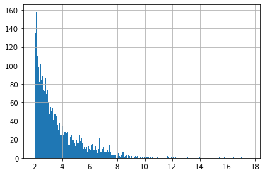

```python
junk = mydf2[ mydf2['Responstid'] > 2]['Responstid'].hist( bins=500)
```

Bortsett fra at vi ble kvitt de 1000 målingene > 25s så er det ikke akkurat noen himmelropende forskjell når vi ignorerer data i Mappe2. Jevnt over *littegrann* bedre.

# Spørsmål

Ut fra loggfilen ser det ikke ut som om jeg kan skille på WMS og WFS-kall, er det mulig å få til? Bør vi måle det separat? Etter mitt hode er det mer kritisk at WFS returnerer kjapt enn at WMS-lag gjør det. Eller tenker jeg feil?

En halv prosent av målingene tilfredsstiller IKKE kravet vårt på to sekunders responstid. Er det for mye til at vi kan akseptere migrering til Atlas?